# 9 Unsupervised Learning

The classification models we’ve discussed are all supervised learning techniques. The word *supervised* refers to the fact that we know the response variable of all of the training observations. Next up, we’ll discuss clustering which is an *unsupervised* technique – none of the observations have a given response variable. For example, we might want to cluster a few hundred melanoma patients based on their genetic data. We are looking for patterns in who groups together, but we don’t have a preconceived idea of which patients belong to which group.

There are also semi-supervised techniques applied to data which have some observations that are labeled and some that are not. We will not discuss semi-supervised methods in this class.

**Clustering** creates groups of observations via unsupervised methods. We will cover hierarchical clustering, k-means, and k-medoids. We cluster for two main reasons:

- Summary: to describe the data and the observations’ similarities to each other.
- Discovery: to find new ways in which groups of observations are similar.

**Classification – SUPERVISED!** creates predictions (and prediction models) for unknown future observations via supervised methods. With classification the group membership (i.e., response variable) is *known* for all the training data. We covered k-NN, CART, bagging, Random Forests, and SVMs.

## 9.1 Dissimilarities

Many, though not all, clustering algorithms are based on distances between the objects being clustered. Mathematical properties of a distance function are the following. Consider two vectors ${\bf x}$ and ${\bf y}$ (${\bf x}, {\bf y} \in \mathbb{R}^p$), and the distance between them: $d({\bf x}, {\bf y})$.

1. $d({\bf x}, {\bf y}) \geq 0$
2. $d({\bf x}, {\bf y}) = d({\bf y}, {\bf x})$
3. $d({\bf x}, {\bf y}) = 0$ iff ${\bf x} = {\bf y}$
4. $d({\bf x}, {\bf y}) \leq d({\bf x}, {\bf z}) + d({\bf z}, {\bf y})$ for all other vectors ${\bf z}$.

**Triangle Inequality**

The key to proving the triangle inequality for most of the distances relies on the Cauchy-Schwarz inequality.
$$\begin{align}
{\bf x} \cdot {\bf y} &= || {\bf x} || ||{\bf y}|| \cos(\theta) \\
|{\bf x} \cdot {\bf y}| &\leq || {\bf x} || ||{\bf y}||
\end{align}$$

#### Euclidean Distance

$$d_E({\bf x}, {\bf y}) = \sqrt{\sum_{i=1}^p (x_i - y_i)^2}$$

Distance properties all check out.

4. Cauchy-Schwarz:
   $$\begin{align}
   \sum_{i=1}^p(x_i - y_i)^2 = \sum_{i=1}^p ( (x_i - z_i) + (z_i - y_i))^2 &\leq \Bigg( \sqrt{\sum_{i=1}^p(x_i - z_i)^2} + \sqrt{\sum_{i=1}^p(z_i - y_i)^2} \Bigg)^2\\
   \sqrt{\sum_{i=1}^p(x_i - y_i)^2} &\leq \sqrt{\sum_{i=1}^p(x_i - z_i)^2} + \sqrt{\sum_{i=1}^p(z_i - y_i)^2}\\
   d_E({\bf x}, {\bf y}) &\leq d_E({\bf x}, {\bf z}) + d_E({\bf z}, {\bf y})
   \end{align}$$

**Shortcomings:**

- $d_E$ is not scale invariant.
- $d_E$ measures magnitude differences, not pattern differences.
- $d_E$ is sensitive to outliers.

**Strengths:**

- Directly measures what is commonly considered to be “distance.”

#### Pearson Correlation Distance

$$\begin{align}
d_P({\bf x}, {\bf y}) &= 1 - r_P ({\bf x}, {\bf y})\\
\mbox{ or } &= 1 - |r_P ({\bf x}, {\bf y})|\\
\mbox{ or } &= 1 - (r_P ({\bf x}, {\bf y}))^2\\
\end{align}$$

Notice that Euclidean distance and Pearson correlation distance are similar if the original observations are scaled. Assume that the sample mean for ${\bf x}$ (that is, $\frac{1}{p} \sum x_i = \overline{x} = 0$) is zero and the sample standard deviation is 1.

$$\begin{align}
r_P ({\bf x}, {\bf y}) &= \frac{\sum x_i y_i - p \ \overline{x} \ \overline{y}}{(p-1)s_x s_y}\\
&= \frac{1}{(p-1)} \sum x_i y_i\\
& \ \ & \\
d_E({\bf x}, {\bf y}) &= \sqrt{\sum(x_i - y_i)^2}\\
&= \sqrt{ \sum x_i^2 + \sum y_i^2 - 2 \sum x_i y_i}\\
d_E^2 &= 2[(p-1) - \sum x_i y_i]\\
&= 2(p-1)*[1 - r_P({\bf x}, {\bf y})]
\end{align}$$

##### Distance properties don’t hold for Pearson correlation

3. ${\bf y}=a{\bf x}$
   $$\begin{align}
   d_P({\bf x}, {\bf y}) &= 1 - r_P ({\bf x}, {\bf y})\\
   &= 1 - r_P ({\bf x}, a{\bf x})\\
   &= 1 - 1 = 0
   \end{align}$$
4. ${\bf x}=(1,1,0)$, ${\bf y} = (2,1,0)$, ${\bf z} = (1,-1,0)$ $r_P({\bf x}, {\bf y}) = 0.87$, $r_P({\bf x}, {\bf z}) = 0$, $r_P({\bf y}, {\bf z}) = 0.5$

$d_P({\bf x}, {\bf y}) + d_P({\bf y}, {\bf z}) < d_P({\bf z}, {\bf x})$ $\rightarrow\leftarrow$

**Regular Pearson distance**

```r
x1 <- c(1,2,3)
x2 <- c(1, 4, 10)
x3 <- c(9, 2, 2)

# d(1,2)
1 - cor(x1, x2)
```

```
[1] 0.01801949
```

```r
# d(1,3)
1 - cor(x1, x3)
```

```
[1] 1.866025
```

```r
# d(2,3)
1 - cor(x2, x3)
```

```
[1] 1.755929
```

```r
# d(1,3) > d(1,2) + d(2,3)
1 - cor(x1, x2) + 1 - cor(x2, x3)
```

```
[1] 1.773948
```

**Absolute Pearson distance**

Using absolute distance doesn’t fix things.

```r
# d(1,2)
1 - abs(cor(x1, x2))
```

```
[1] 0.01801949
```

```r
# d(1,3)
1 - abs(cor(x1, x3))
```

```
[1] 0.1339746
```

```r
# d(2,3)
1 - abs(cor(x2, x3))
```

```
[1] 0.2440711
```

```r
# d(2,3) > d(1,2) + d(1,3)
1 - abs(cor(x1, x2)) + 1 - abs(cor(x1, x3))
```

```
[1] 0.1519941
```

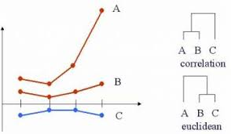

**Shortcomings:**

- $d_P$ does not satisfy the triangle inequality.
- $d_P$ can be zero even if ${\bf x} \ne {\bf y}$ (happens when ${\bf x}$ is a linear combination of ${\bf y}$).
- $d_P$ is sensitive to outliers.

**Strengths:**

- Can measure the distance between variables on different scales (although will still be sensitive to extreme values).

#### Spearman Correlation Distance

Spearman correlation distance uses the Spearman correlation instead of the Pearson correlation. The Spearman correlation is simply the Pearson correlation applied to the ranks of the observations. The ranking allows the Spearman distance to be resistant to outlying observations.

$$\begin{align}
d_S({\bf x}, {\bf y}) &= 1 - r_S ({\bf x}, {\bf y})\\
\mbox{ or } &= 1 - |r_S ({\bf x}, {\bf y})|\\
\mbox{ or } &= 1 - (r_S ({\bf x}, {\bf y}))^2\\
\end{align}$$

**Shortcomings:**

- $d_S$ also does not satisfy the triangle inequality.
- $d_S$ loses information about the shape of the relationship.

**Strengths:**

- Is resistant to outlying values

#### Cosine Distance

Said differently,

$$\begin{align}
d_P({\bf x}, {\bf y}) = d_C({\bf x} - \overline{\bf x}, {\bf y} - \overline{\bf y})
\end{align}$$

#### Haversine Distance

Haversine distance is the great-circle distance (i.e., the distance between two points on a sphere) which is used to measure distance between two locations on the Earth. Let $R$ be the radius of the Earth, and (lat1,long1) and (lat2, long2) be the two locations between which to calculate a distance.

$$d_{HV} = 2 R \arcsin \sqrt{\sin^2 \bigg( \frac{lat2-lat1}{2} \bigg) + \cos(lat1) \cos(lat2) \sin^2 \bigg(\frac{long2 - long1}{2} \bigg)}$$

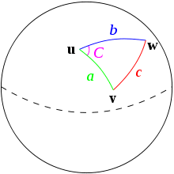

**Shortcomings:**

- Earth is not a perfect sphere
- Depending on how the distance is used, typically getting from one point to the next is not done by the shortest distance

**Strengths:**

- Allows calculations, for example, between two cities.

#### Hamming Distance

Hamming distance is the number of coordinates across two vectors whose values differ. If the vectors are binary, the Hamming distance is equivalent to the $L_1$ norm of the difference. (Hamming distance does satisfy the properties of a distance metric.) Some methods, equivalently, calculate the proportion of coordinates that differ.

$$\begin{align}
d_H({\bf x}, {\bf y}) = \sum_{i=1}^p I(x_i \ne y_i)
\end{align}$$

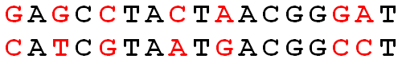

The Hamming distance across the two DNA strands is 7.

**Shortcomings:**

- Can’t measure degree of difference between categorical variables.

**Strengths:**

- It is a (mathematical) distance metric. Gives a more direct “distance” between categorical variables.

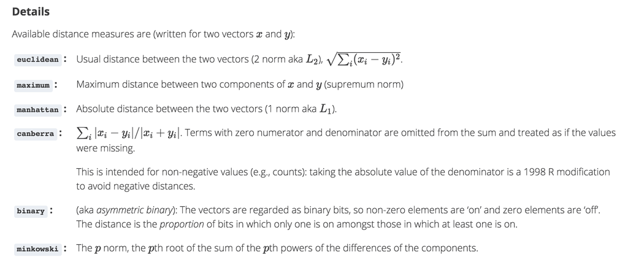

The function `dist` in `R` calculates the distances given above.

#### Distance on strings

Consider the following infographic which compares different methods for computing distances between strings.

[figure not shown]

Comparison of string distance metrics from https://www.kdnuggets.com/2019/01/comparison-text-distance-metrics.html.

## 9.2 Hierarchical Clustering

**Hierarchical Clustering** is a set of nested clusters that are organized as a tree. Note that objects that belong to a child cluster also belong to the parent cluster.

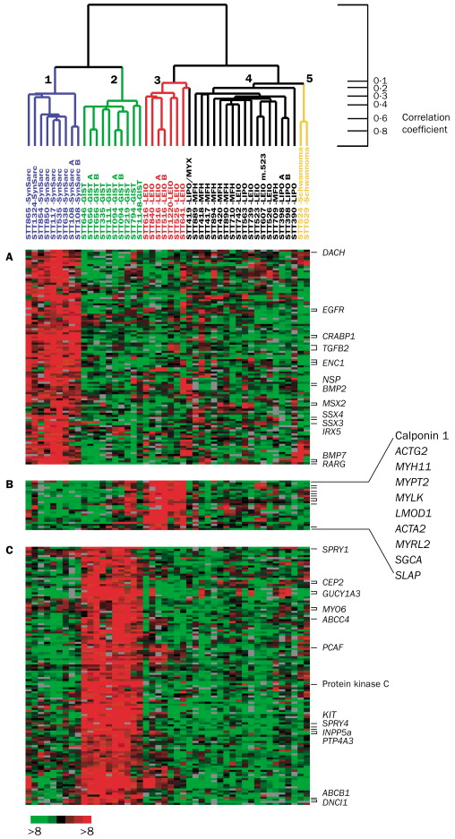

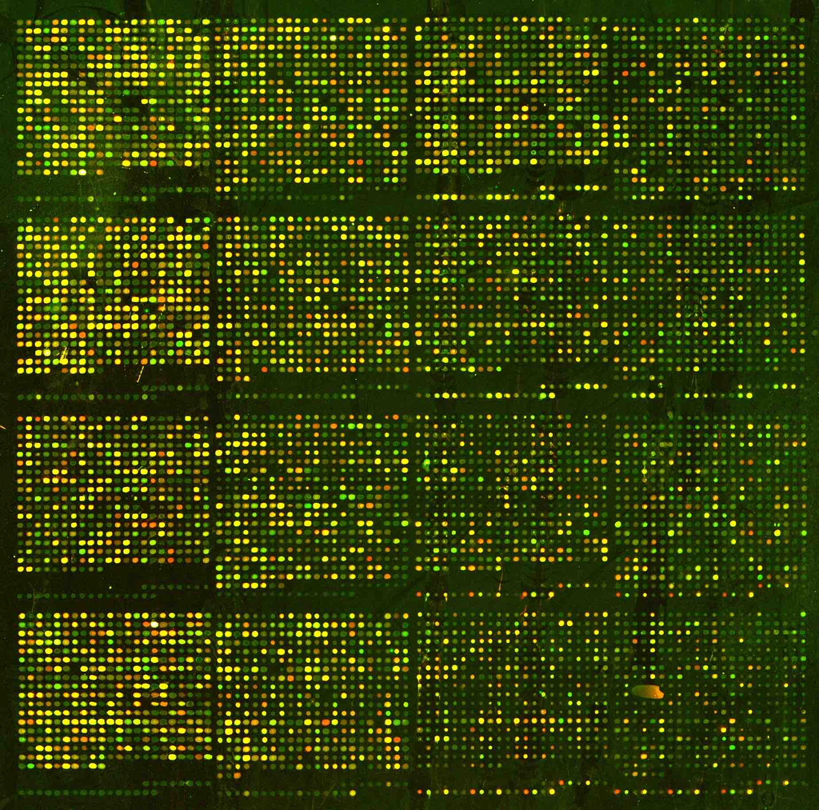

Note: the ordering of the variables (or samples) does not affect the clustering of the samples (or variables). That is: we can clustering the variables / samples either sequentially or in parallel to see trends in both relationships simultaneously. Clustering both the observations and the variables is called *biclustering*.

**Algorithm**: Agglomerative Hierarchical Clustering Algorithm

1. Begin with $n$ observations and a measure (such as Euclidean distance) of all the ${n \choose 2} = n(n-1)/2$ pairwise dissimilarities. Treat each observation as its own cluster.
2. For $i = n, n - 1, \ldots , 2$:
1. Examine all pairwise inter-cluster dissimilarities among the $i$ clusters and identify the pair of clusters that are least dissimilar (that is, most similar). Fuse these two clusters. The dissimilarity between these two clusters indicates the height in the dendrogram at which the fusion should be placed.
2. Compute the new pairwise inter-cluster dissimilarities among the $i - 1$ remaining clusters.

**Agglomerative** methods start with each object (e.g., gene) in its own group. Groups are merged until all objects are together in one group.

**Divisive** methods start with all objects in one group and break up the groups sequentially until all objects are individuals.

**Single Linkage** algorithm defines the distance between groups as that of the closest pair of individuals.

**Complete Linkage** algorithm defines the distance between groups as that of the farthest pair of individuals.

**Average Linkage** algorithm defines the distance between groups as the average of the distances between all pairs of individuals across the groups.

### Should we use hierarchical clustering?

**strengths**

- Provides a clustering for a range of values of $k$.
- Can be used with any distance metric.

**shortcomings**

- Forces a hierarchical structure (almost always agglomerative)
- Linkage choice can change the outcome.

### Toy Example of **Single Linkage Agglomerative Hierarchical Clustering**

|  | A | B | C | D | E |
| --- | --- | --- | --- | --- | --- |
| A | 0 |  |  |  |  |
| B | 0.2 | 0 |  |  |  |
| C | 0.6 | 0.5 | 0 |  |  |
| D | 1 | 0.9 | 0.4 | 0 |  |
| E | 0.9 | 0.8 | 0.5 | 0.3 | 0 |

Link A and B!
$$\begin{align}
d_{(AB)C} &= \min(d_{AC}, d_{BC}) = 0.5\\
d_{(AB)D} &= \min(d_{AD}, d_{BD}) = 0.9\\
d_{(AB)E} &= \min(d_{AE}, d_{BE}) = 0.8\\
\end{align}$$

|  | AB | C | D | E |
| --- | --- | --- | --- | --- |
| AB | 0 |  |  |  |
| C | 0.5 | 0 |  |  |
| D | 0.9 | 0.4 | 0 |  |
| E | 0.8 | 0.5 | 0.3 | 0 |

Link D and E!
$$\begin{align}
d_{(AB)C} &= 0.5\\
d_{(AB)(DE)} &= \min(d_{AD}, d_{BD}, d_{AE}, d_{BE}) = 0.8\\
d_{(DE)C} &= \min(d_{CD}, d_{CE}) = 0.4\\
\end{align}$$

|  | AB | C | DE |
| --- | --- | --- | --- |
| AB | 0 |  |  |
| C | 0.5 | 0 |  |
| DE | 0.8 | 0.4 | 0 |

Link C with (DE)!
$$\begin{align}
d_{(AB)(CDE)} = d_{BC} = 0.5
\end{align}$$

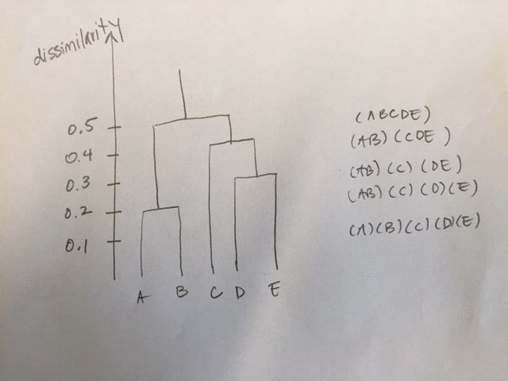

### 9.2.1 Prediction

To predict the cluster assignment for a new observation, we find the closest cluster. How we measure “closeness” is dependent on the specified type of linkage in the model:

- **single linkage**: The new observation is assigned to the same cluster as its nearest observation from the training data.
- **complete linkage**: The new observation is assigned to the cluster with the smallest maximum dissimilarities between training observations and the new observation.
- **average linkage**: The new observation is assigned to the cluster with the smallest average dissimilarities between training observations and the new observation.
- **centroid method**: The new observation is assigned to the cluster with the closest centroid, as in prediction for k_means.
- **Ward’s method**: The new observation is assigned to the cluster with the smallest increase in error sum of squares (ESS) due to the new addition. The ESS is computed as the sum of squared Euclidean distances between observations in a cluster, and the centroid of the cluster.

### 9.2.2 Predictions can be wonky

It’s important to note that there is no guarantee that `predict()` on the training data will produce the same results as `extract_cluster_assignments()`. The process by which clusters are created during the agglomerations results in a particular partition; but if a training observation is treated as new data, it is predicted in the same manner as truly new information.

Consider a silly example using **complete** linkage:

$$x_1 = 1, x_2 = 2, x_3 = 5, x_4 = 9, x_5 = 10, x_6 = -3$$

- Initial clusers ($k=6$), each point is in their own cluster.
- $k = 4$: $\{x_1, x_2 \}$ and $\{ x_3 \}$ and $\{x_4, x_5 \}$ and $\{x_6\}$
- $k=3$: $\{x_1, x_2, x_3 \}$ and $\{x_4, x_5 \}$ and $\{x_6 \}$
- $k=2$: $\{x_1, x_2, x_3, x_6 \}$ and $\{x_4, x_5 \}$

Now consider a new observation, $x^* = x_3 = 5$. Using **complete** linkage, $x^*$ is closer to $\{x_4, x_5 \}$ (distance = 5) than to $\{x_1, x_2, x_3, x_6 \}$ (distance = 8).

### 9.2.3 R hierarchical Example

Again, using the `penguins` dataset, hierarchical clustering will be run. We can look at the dendrogram, in particular its alignment to the categorical variables like `species` and `island`.

Notice that we are only using the numerical variables. And the numerical variables have been scaled (subtract the mean and divide by the standard deviation).

Full example has been adapted from https://tidyclust.tidymodels.org/articles/hier_clust.html. You’ll need the **tidyclust** R package.

**data**

```r
penguins <- penguins |>
  select(bill_length_mm, bill_depth_mm,
         flipper_length_mm, body_mass_g,
         island, species) |>
  drop_na()
```

**recipe**

```r
hc_rec <- recipe(~ ., data = penguins) |>
  update_role(island, new_role = "ID") |>
  update_role(species, new_role = "ID") |>
  step_rm(all_nominal()) |>
  step_normalize(all_predictors())
```

**model**

```r
hc_model <- hier_clust(
  num_clusters = 3,
  linkage_method = "average") |>
  set_engine("stats")

hc_model
```

```
Hierarchical Clustering Specification (partition)

Main Arguments:
  num_clusters = 3
  linkage_method = average

Computational engine: stats
```

**workflow**

```r
hc_work <- workflow() |>
  add_recipe(hc_rec) |>
  add_model(hc_model)

hc_work
```

```
══ Workflow ════════════════════════════════════════════════════════════════════
Preprocessor: Recipe
Model: hier_clust()

── Preprocessor ────────────────────────────────────────────────────────────────
2 Recipe Steps

• step_rm()
• step_normalize()

── Model ───────────────────────────────────────────────────────────────────────
Hierarchical Clustering Specification (partition)

Main Arguments:
  num_clusters = 3
  linkage_method = average

Computational engine: stats
```

**fit**

```r
hc_fit <- hc_work |>
  fit(data = penguins)

hc_fit |>
  summary()
```

```
        Length Class      Mode
pre     3      stage_pre  list
fit     2      stage_fit  list
post    1      stage_post list
trained 1      -none-     logical
```

```r
hc_fit |> extract_fit_summary() |> str()
```

```
List of 7
 $ cluster_names         : Factor w/ 3 levels "Cluster_1","Cluster_2",..: 1 2 3
 $ centroids             : tibble [3 × 4] (S3: tbl_df/tbl/data.frame)
  ..$ bill_length_mm   : num [1:3] -0.369 0.603 2.253
  ..$ bill_depth_mm    : num [1:3] 0.617 -1.123 -0.368
  ..$ flipper_length_mm: num [1:3] -0.65 1.13 2.05
  ..$ body_mass_g      : num [1:3] -0.612 1.06 1.977
 $ n_members             : int [1:3] 219 119 4
 $ sse_within_total_total: num [1:3] 283.19 111.49 2.01
 $ sse_total             : num 656
 $ orig_labels           : NULL
 $ cluster_assignments   : Factor w/ 3 levels "Cluster_1","Cluster_2",..: 1 1 1 1 1 1 1 1 1 1 ...
```

**centroids**

```r
hc_fit |> extract_centroids()
```

```
# A tibble: 3 × 5
  .cluster  bill_length_mm bill_depth_mm flipper_length_mm body_mass_g
  <fct>              <dbl>         <dbl>             <dbl>       <dbl>
1 Cluster_1         -0.369         0.617            -0.650      -0.612
2 Cluster_2          0.603        -1.12              1.13        1.06
3 Cluster_3          2.25         -0.368             2.05        1.98
```

**Prediction**

```r
hc_preds <- hc_fit |> predict(penguins)

hc_preds
```

```
# A tibble: 342 × 1
   .pred_cluster
   <fct>
 1 Cluster_1
 2 Cluster_1
 3 Cluster_1
 4 Cluster_1
 5 Cluster_1
 6 Cluster_1
 7 Cluster_1
 8 Cluster_1
 9 Cluster_1
10 Cluster_1
# ℹ 332 more rows
```

**Prediction vs. label**

```r
bind_cols(hc_preds,
  extract_cluster_assignment(hc_fit) ) |>
  select(.pred_cluster, .cluster) |>
  table()
```

```
             .cluster
.pred_cluster Cluster_1 Cluster_2 Cluster_3
    Cluster_1       218         0         0
    Cluster_2         0        99         0
    Cluster_3         1        20         4
```

#### Plotting

The basic dendrogram:

We have to get the `hclust` “object” from the fit, and transform it to make the dendrogram.

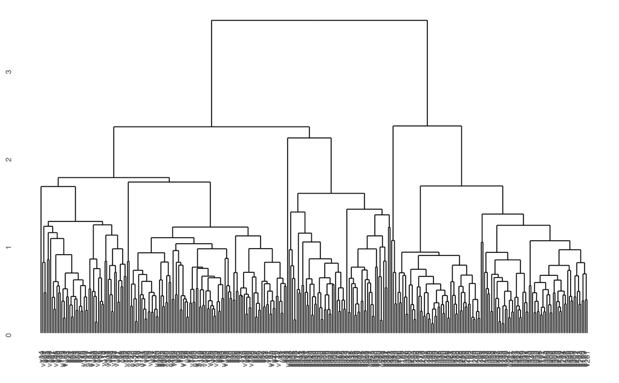

```r
library(ggdendro)

penguin_hclust <- hc_fit |>
  extract_fit_engine()

penguin_dend <- penguin_hclust |>
  as.dendrogram()

ggdendro::ggdendrogram(penguin_dend)
```

Zooming in on a cluster:

**left**

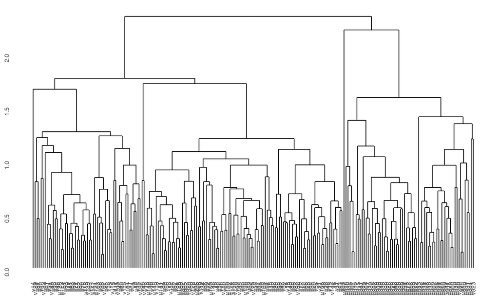

```r
ggdendrogram(penguin_dend[[1]])
```

**right**

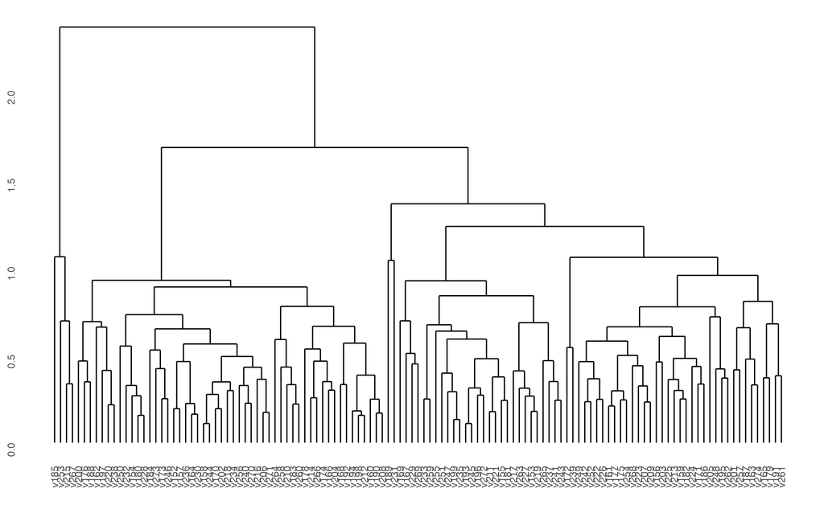

```r
ggdendrogram(penguin_dend[[2]])
```

**left-left**

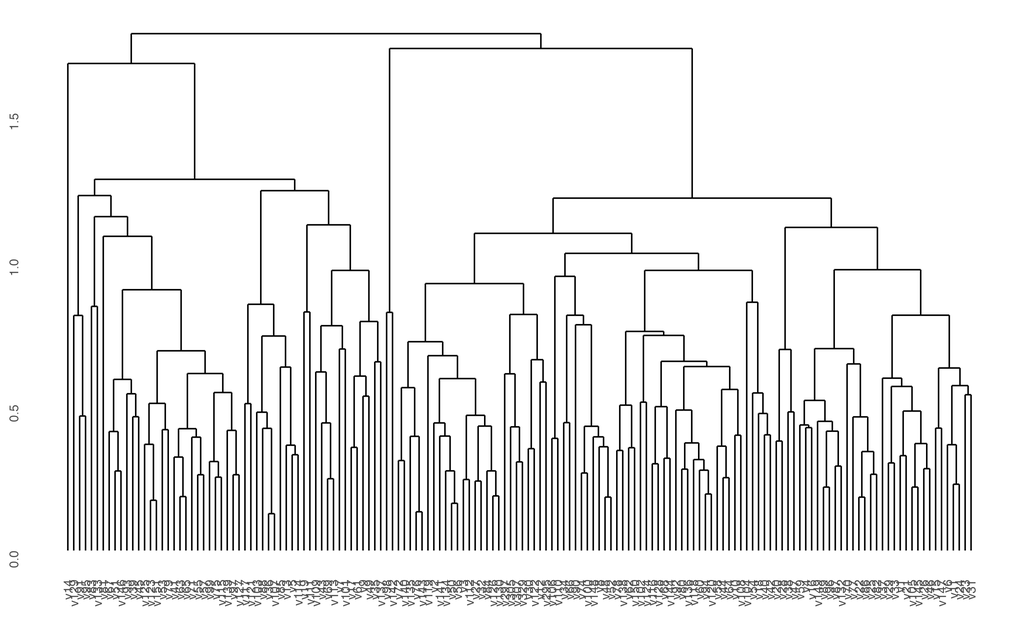

```r
ggdendrogram(penguin_dend[[1]][[1]])
```

Adding color to branches and nodes

```r
library(colorspace) # get nice colors
species_col <- rev(rainbow_hcl(3))[as.numeric(penguins$species)]
```

```r
library(dendextend)
# order the branches as closely as possible to the original order
penguin_dend <- rotate(penguin_dend, 1:342)
```

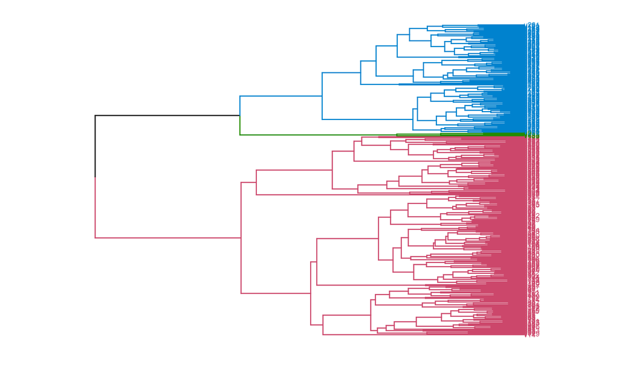

```r
library(dendextend)
penguin_dend |>
  set("branches_k_color", k = 3) |>  # color of the branches
  set("labels_colors", k = 3) |>     # color of the labels
  set("branches_lwd", 0.3) |>        # width of the branches
  set("labels_cex", 0.3) |>          # size of the label
  as.ggdend() |>
  ggplot(horiz = TRUE)
```

### Checkign the clustering

We don’t usually have a way to check (i.e., “unsupervised”)!

```r
penguins |>
  drop_na(bill_length_mm, bill_depth_mm, flipper_length_mm, body_mass_g) |>
  select(island) |>
  cbind(cluster = cutree(penguin_hclust, k = 3) ) |>
  table()
```

```
           cluster
island        1   2   3
  Biscoe     44 119   4
  Dream     124   0   0
  Torgersen  51   0   0
```

```r
penguins |>
  drop_na(bill_length_mm, bill_depth_mm, flipper_length_mm, body_mass_g) |>
  select(species) |>
  cbind(cluster = cutree(penguin_hclust, k = 3) ) |>
  table()
```

```
           cluster
species       1   2   3
  Adelie    151   0   0
  Chinstrap  68   0   0
  Gentoo      0 119   4
```

## 9.3 Partitioning Clustering

**Partition Clustering** is a division of the set of data objects into $K$ non-overlapping subsets (clusters) with each observation falling into exactly one cluster.

In contrast to hierarchical clustering where results were given for any (and all!) number of clusters, partitioning methods typically start with a given $k$ value and a set of distances. The goal is to partition the observations into $k$ groups such that an objective function is optimized. The number of possible partitions is roughly to $n^k / k!$ (note: $100^{5} / 5! = 83$ million). [The exact number can be computed using Sterling numbers.] So instead of looking through all of the partitions, we step through a recursive algorithm.

### 9.3.1 $k$-means Clustering

A fun applet!!

https://www.naftaliharris.com/blog/visualizing-k-means-clustering/

$k$-means clustering is an unsupervised partitioning algorithm designed to find a partition of the observations such that the following objective function is minimized (find the smallest within cluster sum of squares):

$$\text{arg}\,\min\limits_{C_1, \ldots, C_k} \Bigg\{ \sum_{k=1}^K 2 \sum_{i \in C_k} \sum_{j=1}^p (x_{ij} - \overline{x}_{kj})^2 \Bigg\}$$

As described in the algorithm below, reallocating observations can only improve the minimization criteria with the algorithm stopping when no changes of the observations will lower the objective function. The algorithm leads to a *local optimum*, with no confirmation that the global minimum has occurred. Often the $k$- means algorithm is run multiple times with different random starts, and the partition leading to the lowest objective criteria is chosen.

Note that the following algorithm is simply one $k$-means algorithm. Other algorithms could include a different way to set the starting values, a different decision on when to recalculate the centers, what to do with ties, etc.

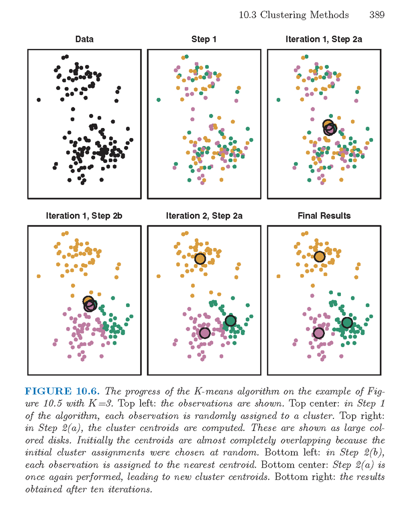

From *An Introduction to Statistical Learning* by James, Witten, Hastie, and Tibshirani.

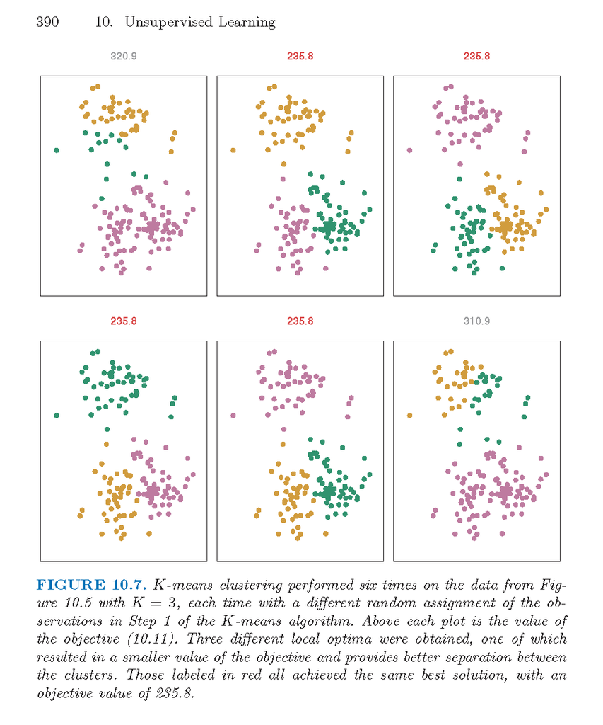

From *An Introduction to Statistical Learning* by James, Witten, Hastie, and Tibshirani.

**Algorithm**: $k$-Means Clustering

1. Randomly assign a number, from 1 to $k$, to each of the observations. These serve as initial cluster assignments for the observations.
2. Iterate until the cluster assignments stop changing:
   1. For each of the $k$ clusters, compute the cluster centroid. The $k^{th}$ cluster centroid is the vector of the $p$ feature means for the observations in the $k^{th}$ cluster.
   2. Assign each observation to the cluster whose centroid is closest (where closest is defined using Euclidean distance).
3. Ties? Do something consistent: for example, leave in the current cluster.

Why does the $k$-means algorithm converge / (local) minimize the objective function?

1. If a point is closer to a different center, moving it will lower the objective function.
2. Averages minimize squared differences, so taking the new average will result in a lower objective function.
3. If a point is equidistant from two clusters, the point won’t move.
4. The algorithm must converge in finite number of steps because there are finitely many points.

#### Scaling matters

Note that if the variables are on very different scales, whichever variable is larger in magnitude will dominate the distances (and therefore the clustering). Unless you *explicitly* want that to happen (which would be odd), you should scale the variables (subtract the mean and divide by the standard deviation) so that the distance is calculated on Z-scores instead of on the raw data.

In the example below, the $k=2$ k-means algorithm is not able to see the cigar-shaped structure (on the raw data) because the distances are dominated by the x1 variable (which does not differentiate the clusters).

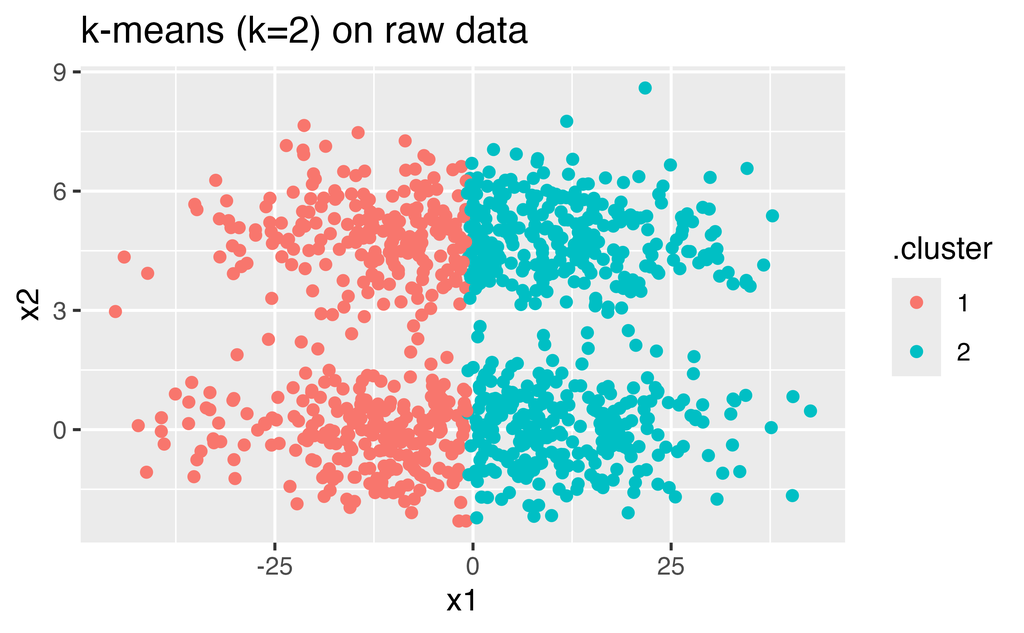

```r
set.seed(47)
norm_clust <- data.frame(
  x1 = rnorm(1000, 0, 15),
  x2 = c(rnorm(500, 5, 1), rnorm(500, 0, 1)))

norm_clust |>
  kmeans(centers = 2) |>
  augment(norm_clust) |>
  ggplot() +
  geom_point(aes(x = x1, y = x2, color = .cluster)) +
  ggtitle("k-means (k=2) on raw data")
```

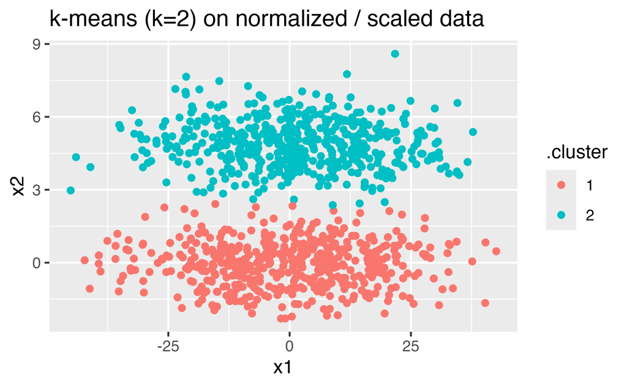

```r
norm_clust |>
  mutate(across(everything(), scale)) |>
  kmeans(centers = 2) |>
  augment(norm_clust) |>
  ggplot() +
  geom_point(aes(x = x1, y = x2, color = .cluster)) +
  ggtitle("k-means (k=2) on normalized / scaled data")
```

### Should we use k-means?

**strengths**

- No hierarchical structure / points can move from one cluster to another.
- Can run for a range of values of $k$.

**shortcomings**

- $k$ has to be predefined to run the algorithm.
- $k$-means is based on Euclidean distance (*only*).

### 9.3.2 R k-means Example

Again, using the `penguins` dataset, $k$-means clustering will be run. We try multiple different values of $k$ to come up with a partition of the penguins. We can look at the clusterings on scatterplots of the numerical variables. We can also check to see if the clustering aligns with the categorical variables like `species` and `island`.

Notice that we are only using the numerical variables. And the numerical variables have been scaled (subtract the mean and divide by the standard deviation).

Full example has been adapted from https://tidyclust.tidymodels.org/articles/k_means.html.

**recipe**

```r
kmean_rec <- recipe(~ ., data = penguins) |>
  step_naomit(all_predictors()) |>
  update_role(island, new_role = "ID") |>
  update_role(species, new_role = "ID") |>
  update_role(sex, new_role = "ID") |>
  step_rm(all_nominal()) |>
  step_normalize(all_predictors())
```

**model**

`stats` engine lets us `tidy()` and `glance()` and `augment()`. With the `ClusterR` engine, we can only `augment()` (see below).

```r
kmean_model <- k_means(
  num_clusters = 3) |>
  set_engine("stats")
#  set_engine("ClusterR", initializer = "random") # need the ClusterR package

kmean_model
```

```
K Means Cluster Specification (partition)

Main Arguments:
  num_clusters = 3

Computational engine: stats
```

**workflow**

```r
kmean_work <- workflow() |>
  add_recipe(kmean_rec) |>
  add_model(kmean_model)

kmean_work
```

```
══ Workflow ════════════════════════════════════════════════════════════════════
Preprocessor: Recipe
Model: k_means()

── Preprocessor ────────────────────────────────────────────────────────────────
3 Recipe Steps

• step_naomit()
• step_rm()
• step_normalize()

── Model ───────────────────────────────────────────────────────────────────────
K Means Cluster Specification (partition)

Main Arguments:
  num_clusters = 3

Computational engine: stats
```

**fit 1**

```r
kmean_fit <- kmean_work |>
  fit(data = penguins)

kmean_fit |>
  summary()
```

```
        Length Class      Mode
pre     3      stage_pre  list
fit     2      stage_fit  list
post    1      stage_post list
trained 1      -none-     logical
```

**fit 2**

```r
kmean_summary <- kmean_fit |> extract_fit_summary()

kmean_summary |> str()
```

```
List of 7
 $ cluster_names         : Factor w/ 3 levels "Cluster_1","Cluster_2",..: 1 2 3
 $ centroids             : tibble [3 × 5] (S3: tbl_df/tbl/data.frame)
  ..$ bill_length_mm   : num [1:3] -1.046 0.621 0.656
  ..$ bill_depth_mm    : num [1:3] 0.474 0.825 -1.098
  ..$ flipper_length_mm: num [1:3] -0.911 -0.268 1.157
  ..$ body_mass_g      : num [1:3] -0.787 -0.357 1.09
  ..$ year             : num [1:3] -0.0923 0.0605 0.0538
 $ n_members             : int [1:3] 130 89 123
 $ sse_within_total_total: num [1:3] 252 209 257
 $ sse_total             : num 1705
 $ orig_labels           : int [1:342] 1 1 1 1 1 1 1 1 2 1 ...
 $ cluster_assignments   : Factor w/ 3 levels "Cluster_1","Cluster_2",..: 1 1 1 1 1 1 1 1 2 1 ...
```

**centroids**

```r
kmean_fit |> extract_centroids()
```

```
# A tibble: 3 × 6
  .cluster  bill_length_mm bill_depth_mm flipper_length_mm body_mass_g    year
  <fct>              <dbl>         <dbl>             <dbl>       <dbl>   <dbl>
1 Cluster_1         -1.05          0.474            -0.911      -0.787 -0.0923
2 Cluster_2          0.621         0.825            -0.268      -0.357  0.0605
3 Cluster_3          0.656        -1.10              1.16        1.09   0.0538
```

The function `augment()` works at the per-observation level:

```r
kmean_fit |> augment(new_data = penguins |> drop_na())
```

```
# A tibble: 333 × 9
   .pred_cluster species island   bill_length_mm bill_depth_mm flipper_length_mm
   <fct>         <fct>   <fct>             <dbl>         <dbl>             <int>
 1 Cluster_1     Adelie  Torgers…           39.1          18.7               181
 2 Cluster_1     Adelie  Torgers…           39.5          17.4               186
 3 Cluster_1     Adelie  Torgers…           40.3          18                 195
 4 Cluster_1     Adelie  Torgers…           36.7          19.3               193
 5 Cluster_1     Adelie  Torgers…           39.3          20.6               190
 6 Cluster_1     Adelie  Torgers…           38.9          17.8               181
 7 Cluster_1     Adelie  Torgers…           39.2          19.6               195
 8 Cluster_1     Adelie  Torgers…           41.1          17.6               182
 9 Cluster_1     Adelie  Torgers…           38.6          21.2               191
10 Cluster_1     Adelie  Torgers…           34.6          21.1               198
# ℹ 323 more rows
# ℹ 3 more variables: body_mass_g <int>, sex <fct>, year <int>
```

The function `tidy()` works at the per-cluster level:

```r
kmean_fit |> tidy()
```

```
# A tibble: 3 × 8
  bill_length_mm bill_depth_mm flipper_length_mm body_mass_g    year  size
           <dbl>         <dbl>             <dbl>       <dbl>   <dbl> <int>
1         -1.05          0.474            -0.911      -0.787 -0.0923   130
2          0.621         0.825            -0.268      -0.357  0.0605    89
3          0.656        -1.10              1.16        1.09   0.0538   123
# ℹ 2 more variables: withinss <dbl>, cluster <fct>
```

The function `glance()` works at the per-model level:

```r
kmean_fit |> glance()
```

```
# A tibble: 1 × 4
  totss tot.withinss betweenss  iter
  <dbl>        <dbl>     <dbl> <int>
1 1705.         718.      987.     2
```

#### Trying various values of k

```r
k_func <- function(k = 3, mydata = penguins) {

  workflow() |>
    add_recipe(recipe(~ ., data = mydata) |>   # recipe
             step_naomit(all_predictors()) |>
             update_role(island, new_role = "ID") |>
             update_role(species, new_role = "ID") |>
             update_role(sex, new_role = "ID") |>
             step_rm(all_nominal()) |>
             step_normalize(all_predictors())) |>
    add_model(k_means(num_clusters = k) |>     # model
              set_engine("stats")) |>
    fit(data = mydata |> drop_na())            # fit
}
```

```r
kmax <- 9
penguin_kclusts <-
  tibble(k = 1:kmax) |>
  mutate(
    penguin_kclust = map(k, k_func, mydata = penguins |> drop_na()),
    tidied = map(penguin_kclust, tidy),
    glanced = map(penguin_kclust, glance),
    augmented = map(penguin_kclust, augment, penguins |> drop_na())
  )

penguin_kclusts
```

```
# A tibble: 9 × 5
      k penguin_kclust tidied           glanced          augmented
  <int> <list>         <list>           <list>           <list>
1     1 <workflow>     <tibble [1 × 8]> <tibble [1 × 4]> <tibble [333 × 9]>
2     2 <workflow>     <tibble [2 × 8]> <tibble [1 × 4]> <tibble [333 × 9]>
3     3 <workflow>     <tibble [3 × 8]> <tibble [1 × 4]> <tibble [333 × 9]>
4     4 <workflow>     <tibble [4 × 8]> <tibble [1 × 4]> <tibble [333 × 9]>
5     5 <workflow>     <tibble [5 × 8]> <tibble [1 × 4]> <tibble [333 × 9]>
6     6 <workflow>     <tibble [6 × 8]> <tibble [1 × 4]> <tibble [333 × 9]>
7     7 <workflow>     <tibble [7 × 8]> <tibble [1 × 4]> <tibble [333 × 9]>
8     8 <workflow>     <tibble [8 × 8]> <tibble [1 × 4]> <tibble [333 × 9]>
9     9 <workflow>     <tibble [9 × 8]> <tibble [1 × 4]> <tibble [333 × 9]>
```

For each of the values of $k$ the `augment`ed, `tidy`ed, and `glance`d information can be calculated. Note that you might want to find how the total within sum of squares decreases as a function of $k$. (Will the within sum of squares always decrease as a function of $k?$ Does it here? Why not?) It seems as though $k=3$ or $k=4$ is probably sufficient (larger values of $k$ do not reduce the sums of squares substantially).

```r
clusters <-
  penguin_kclusts |>
  unnest(cols = c(tidied))

assignments <-
  penguin_kclusts |>
  unnest(cols = c(augmented))

clusterings <-
  penguin_kclusts |>
  unnest(cols = c(glanced))
```

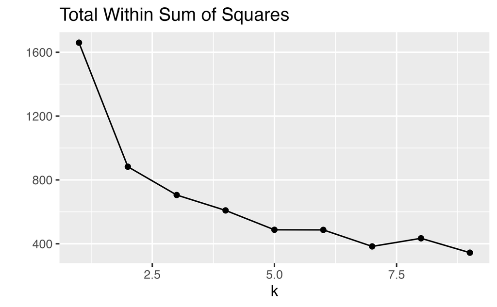

```r
clusterings |>
  ggplot(aes(x = k, y = tot.withinss)) +
  geom_line() +
  geom_point() + ylab("") +
  ggtitle("Total Within Sum of Squares")
```

From the two variables `flipper_length_mm` and `bill_lengh_mm` it seems that two clusters is probably sufficient. However, it would probably make sense to look at the cluster colorings across all four of the variables and in higher dimensional space (e.g., 3-D projections).

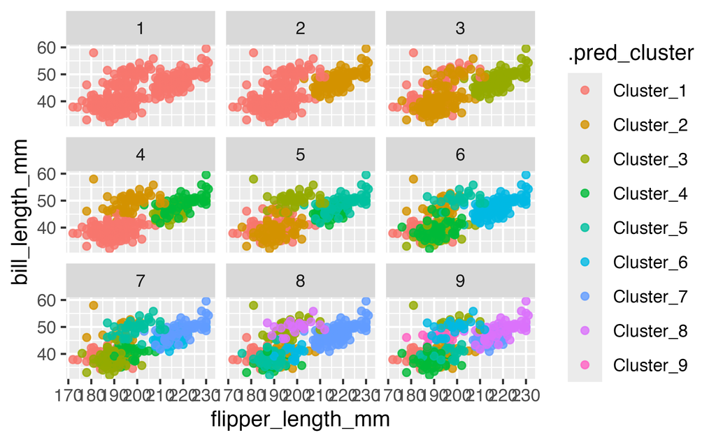

```r
assignments |>
 ggplot(aes(x = flipper_length_mm, y = bill_length_mm)) +
  geom_point(aes(color = .pred_cluster), alpha = 0.8) +
  facet_wrap(~ k)
```

Based on `species`, the clustering ($k=2$) seems to separate out Gentoo, but it can’t really differentiate Adelie and Chinstrap. If we let $k=4$, we get an almost perfect partition of the three species.

```r
assignments |>
  filter(k == 4) |>
  select(.pred_cluster, species) |>
  table()
```

```
             species
.pred_cluster Adelie Chinstrap Gentoo
    Cluster_1    138         7      0
    Cluster_2      8        61      0
    Cluster_3      0         0     60
    Cluster_4      0         0     59
    Cluster_5      0         0      0
    Cluster_6      0         0      0
    Cluster_7      0         0      0
    Cluster_8      0         0      0
    Cluster_9      0         0      0
```

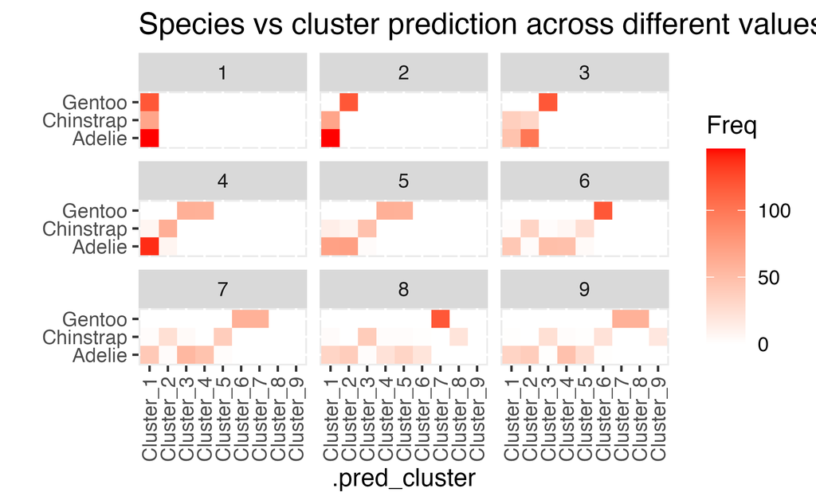

```r
assignments |>
  group_by(k) |>
  select(.pred_cluster, species) |>
  table() |>
  as.data.frame() |>
    ggplot() +
    geom_tile(aes(x = .pred_cluster, y = species, fill = Freq)) +
  facet_wrap( ~ k) + ylab("") +
  scale_fill_gradient(low = "white", high = "red") +
  theme(axis.text.x = element_text(angle = 90, vjust = 0.5, hjust = 1)) +
  ggtitle("Species vs cluster prediction across different values of k")
```

```r
assignments |>
  filter(k == 4) |>
  select(.pred_cluster, island) |>
  table()
```

```
             island
.pred_cluster Biscoe Dream Torgersen
    Cluster_1     42    60        43
    Cluster_2      2    63         4
    Cluster_3     60     0         0
    Cluster_4     59     0         0
    Cluster_5      0     0         0
    Cluster_6      0     0         0
    Cluster_7      0     0         0
    Cluster_8      0     0         0
    Cluster_9      0     0         0
```

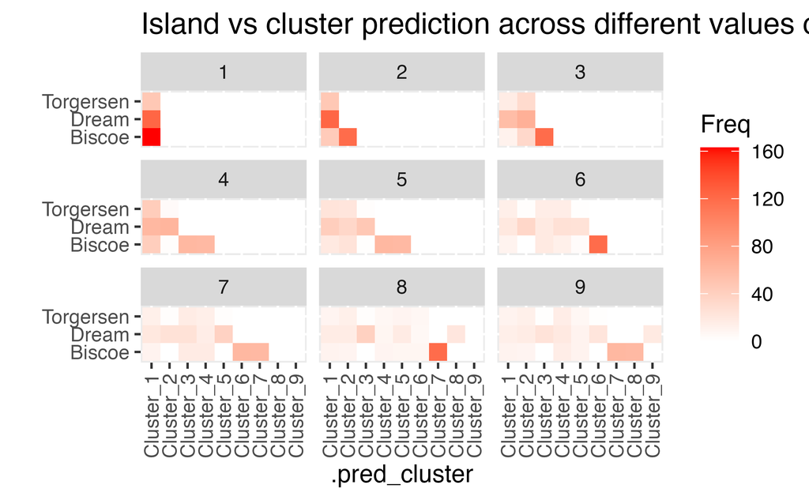

```r
assignments |>
  group_by(k) |>
  select(.pred_cluster, island) |>
  table() |>
  as.data.frame() |>
    ggplot() +
    geom_tile(aes(x = .pred_cluster, y = island, fill = Freq)) +
  facet_wrap( ~ k) + ylab("") +
  scale_fill_gradient(low = "white", high = "red") +
  theme(axis.text.x = element_text(angle = 90, vjust = 0.5, hjust = 1)) +
  ggtitle("Island vs cluster prediction across different values of k")
```

### 9.3.3 Partitioning Around Medoids

As an alternative to $k$-means, Kaufman and Rousseeuw developed Partitioning around Medoids (*Finding Groups in Data: an introduction to cluster analysis*, 1990). The particular strength of PAM is that it allows for *any* dissimilarity metric. That is, a dissimilarity based on correlations is no problem, but the algorithm gets more complicated because the “center” is no longer defined in Euclidean terms.

The two main steps are to Build (akin to assigning points to clusters) and to Swap (akin to redefining cluster centers). The objective function the algorithm tries to minimize is the average dissimilarity of objects to the closest representative object. (The PAM algorithm is a good (not necessarily global optimum) solution to minimizing the objective function.)
$$\text{arg}\,\min\limits_{C_1, \ldots, C_k} \Bigg\{ \sum_{k=1}^K \sum_{i \in C_k}D_i \Bigg\} = \text{arg}\,\min\limits_{C_1, \ldots, C_k} \Bigg\{ \sum_{k=1}^K \sum_{i \in C_k}d(x_i, m_k) \Bigg\}$$
Where $D_i$ represents this distance from observation $i$ to the closest medoid, $m_k$.

**$m_k$ is an observation!**

$m_k$ is a data point. It is not an average of points or any other summary statistic.

### Should we use PAM?

**strengths**

- No hierarchical structure / points can move from one cluster to another.
- Can run for a range of values of $k$.
- It can use any distance measure.

**shortcomings**

- $k$ has to be predefined to run the algorithm.

**Algorithm**: Partitioning Around Medoids (From *The Elements of Statistical Learning* (2001), by Hastie, Tibshirani, and Friedman, pg 469.)

1. Randomly assign a number, from 1 to $K$, to each of the observations. These serve as initial cluster assignments for the observations.
2. Iterate until the cluster assignments stop changing:
1. (Repeat for $k \in \{1, 2, ...K\}$) For a given cluster, $C_k$, find the observation in the cluster minimizing total distance to other points in that cluster:
   $$i^*_k = \text{arg}\,\min\limits_{i \in C_k} \sum_{i' \in C_k} d(x_i, x_{i'})$$
   Then $m_k = x_{i^*_k}, k=1, 2, \ldots, K$ are the current estimates of the cluster centers.
2. Given a current set of cluster centers $\{m_1, m_2, \ldots, m_K\}$, minimize the total error by assigning each observation to the closest (current) cluster center:
   $$C_i = \text{arg}\,\min\limits_{1 \leq k \leq K} d(x_i, m_k)$$

## 9.4 Evaluation Metrics

- Silhouette Width

Consider observation $i \in$ cluster $Clus1$. Let
$$\begin{align}
d(i, Clus2) &= \mbox{average dissimilarity of } i \mbox{ to all objects in cluster } Clus2\\
a(i) &= \mbox{average dissimilarity of } i \mbox{ to all objects in } Clus1.\\
b(i) &= \min_{Clus2 \ne Clus1} d(i,Clus2) = \mbox{distance to the next closest neighbor cluster}\\
\mbox{ silhouette width} &= s(i) = \frac{b(i) - a(i)}{\max \{ a(i), b(i) \}}\\
& &\\
\mbox{average}_{i \in Clus1} s(i) &= \mbox{average silhouette width for cluster $Clus1$}
\end{align}$$
Note that if $a(i) < b(i)$ then $i$ is well classified with a maximum $s(i) = 1$. If $a(i) > b(i)$ then $i$ is *not* well classified with a minimum $s(i) = -1$.

The goal is to have a large silhouette width.

- Diameter of cluster $Clus1$ (within cluster measure)
  $$\begin{align}
  \mbox{diameter} = \max_{i,j \in Clus1} d(i,j)
  \end{align}$$
- Separation of cluster $Clus1$ (between cluster measure)
  $$\begin{align}
  \mbox{separation} = \min_{i \in Clus1, j \notin Clus1} d(i,j)
  \end{align}$$
- $L^*$: a cluster with diameter $<$ separation; $L$: a cluster with $\max_{j \in Clus1} d(i,j) < \min_{k \notin Clus1} d(i,k)$.

#### PAM example

##### Building the clusters

|  | A | B | C | D | E |
| --- | --- | --- | --- | --- | --- |
| A | 0 |  |  |  |  |
| B | 0.2 | 0 |  |  |  |
| C | 0.6 | 0.5 | 0 |  |  |
| D | 1 | 0.9 | 0.4 | 0 |  |
| E | 0.9 | 0.8 | 5 | 0.3 | 0 |

- Start by considering the random allocation (AC) and (BDE)
- As a second step, calculate the within cluster sums of distances:

A: 0.6

C: 0.6

B: 0.9 + 0.8 = 1.7

D: 0.9 + 0.3 = 1.2

E: 0.8 + 0.3 = 1.1

For cluster 1, it doesn’t matter if we choose A or C (let’s choose C). For cluster 2, we should choose E (it is the most “central” as measured by its closer distance to both B and D).

- Reallocate points:

Cluster1: C **and** all the points that are closer to C than E. A and B are both closer to C than to E. Cluster1 will be (A,B,C).

Cluster2: E **and** all the points that are closer to E than C. Only D is closer to E than C. Cluster2 will be (D,E)

- Redefine cluster centers:

A: 0.2 + 0.6 = 0.8

B: 0.2 + 0.5 = 0.7

C: 0.6 + 0.5 = 1.1

D: 0.3

E: 0.3

Cluster1 now has a medoid of B. Cluster2 (we choose randomly) has a medoid of D.

- Reallocate points:

Cluster1: B **and** A (A,B)

Cluster2: D **and** C, E (D, C, E)

- The medoids are now A or B (randomly choose) and D. The iteration process has converged.

#### Evaluating the clusters

|  | A | B | C | D |
| --- | --- | --- | --- | --- |
| A | 0 |  |  |  |
| B | 0.2 | 0 |  |  |
| C | 0.6 | 0.5 | 0 |  |
| D | 1 | 0.9 | 0.4 | 0 |

(Note: this is the same matrix as before, but with only 4 observations.)

Consider the data with (AB)(CD) as the clusters, we can calculate the previous metrics:

- **Silhouette Width**
  $$\begin{align}
  s(i=A) = \frac{b(A) - a(A)}{\max \{a(A), b(A)\}} = \frac{0.8 - 0.2}{0.8} = 0.75\\
  s(i=B) = \frac{b(B) - a(B)}{\max \{a(B), b(B)\}} = \frac{0.7 - 0.2}{0.7} = 0.71\\
  s(i=C) = \frac{b(C) - a(C)}{\max \{a(C), b(C)\}} = \frac{0.55 - 0.4}{0.55} = .27\\
  s(i=D) = \frac{b(D) - a(D)}{\max \{a(D), b(D)\}} = \frac{0.95 - 0.4}{0.95} = .57\\
  \mbox{Ave SW} = 0.575\\
  \end{align}$$
- **Diameter**
  $$\begin{align}
  \mbox{diameter}(AB) = 0.2\\
  \mbox{diameter}(CD) = 0.4\\
  \end{align}$$
- **Separation**
  $$\begin{align}
  \mbox{separation}(AB) = \mbox{separation}(CD) = 0.5\\
  \end{align}$$

#### Rand Index / Adjusted Rand Index

is based on a confusion matrix comparing either a known truth (labels) or comparing two different clusterings (e.g., comparing $k$-means and hierarchical clustering). Let the two different clusterings be called partition1 and partition2. * **a** is the number of pairs of observations put together in both partition1 and partition2 * **b** is the number of pairs of observations together in partition1 and apart in partition2 * **c** is the number of pairs of observations together in partition2 and apart in partition1 * **d** is the number of pairs of observations apart in both partitions

$$\mbox{Rand index} = \frac{a+d}{a+b+c+d}$$

The cool thing about the Rand index is that the partitions don’t have to even have the same number of clusters. They can be absolutely any two clusterings (one might be known labels, for example). Details on the Adjusted Rand index are given at http://faculty.washington.edu/kayee/pca/supp.pdf (basic idea is to center and scale the Rand index so that the values are more meaningful).

## 9.5 Latent Dirichlet Allocation

LDA views each document as a mixture of a small (predefined) number of topics that describe a set of documents. Each word (typically very common and extremely rare words are removed before modeling) represents a an occurrence generated by one of the document’s topics (where the document is modeled as a mixture of topics). Through LDA, the model learns both the composition of each topic and the topic mixture of each document.

From [Wikipedia](https://en.wikipedia.org/wiki/Latent_Dirichlet_allocation):

> In natural language processing, latent Dirichlet allocation (LDA) is a generative statistical model that allows sets of observations to be explained by unobserved groups that explain why some parts of the data are similar. For example, if observations are words collected into documents, it posits that each document is a mixture of a small number of topics and that each word’s creation is attributable to one of the document’s topics.

### 9.5.1 LDA Algorithm

**Algorithm**: Latent Dirichlet Allocation

1. For each document in the training data, randomly assign each word to one of the $K$ topics.
2. Each of the $K$ topics now has a set of words associated with it (albeit, that set of words is meaningless). To improve on the set of words associated with each topic. For each word $w$ in document $d$:
   1. For each topic $t$, compute two things:
      - p(topic $t$ $|$ document $d$) = the proportion of words in document $d$ that are currently assigned to topic $t$.
      - p(word $w$ $|$ topic $t$) = the proportion of assignments to topic $t$ over all documents that come from this word $w$.
   2. Reassign $w$ to a new topic, where we choose topic $t$ with probability = p(topic $t$ $|$ document $d$) * p(word $w$ $|$ topic $t$) (according to our generative model, this is essentially the probability that topic $t$ generated word $w$, so it makes sense that we resample the current word’s topic with this probability).
   3. In other words, in this step, we’re assuming that all topic assignments except for the current word in question are correct, and then updating the assignment of the current word using our model of how documents are generated.
3. After repeating the previous steps a large number of times, the list of words in each topic will reach a steady state. The resulting assignments estimate the topic mixtures of each document (by counting the proportion of words assigned to each topic within that document) and the words associated to each topic (by counting the proportion of words assigned to each topic overall).

### 9.5.2 Toy example of LDA

How can we figure out (unsupervised!) the underlying topic of each of a set of documents?[^1]

#### Data

Start with documents that each contain words:

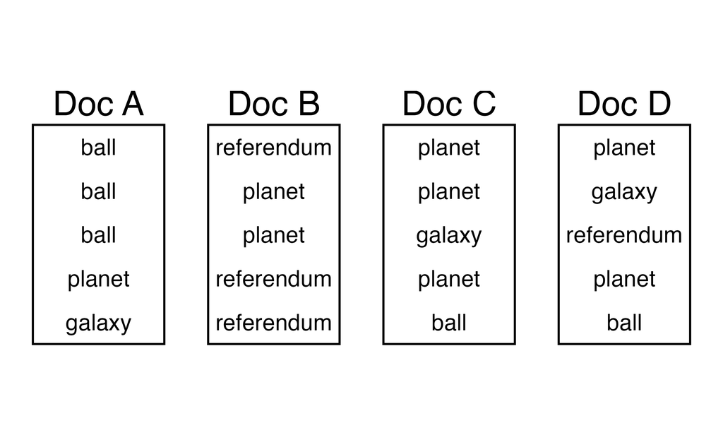

#### Assign topics

As a human, assign topics: Science, Politics, Sports. Here is one potential assignment:

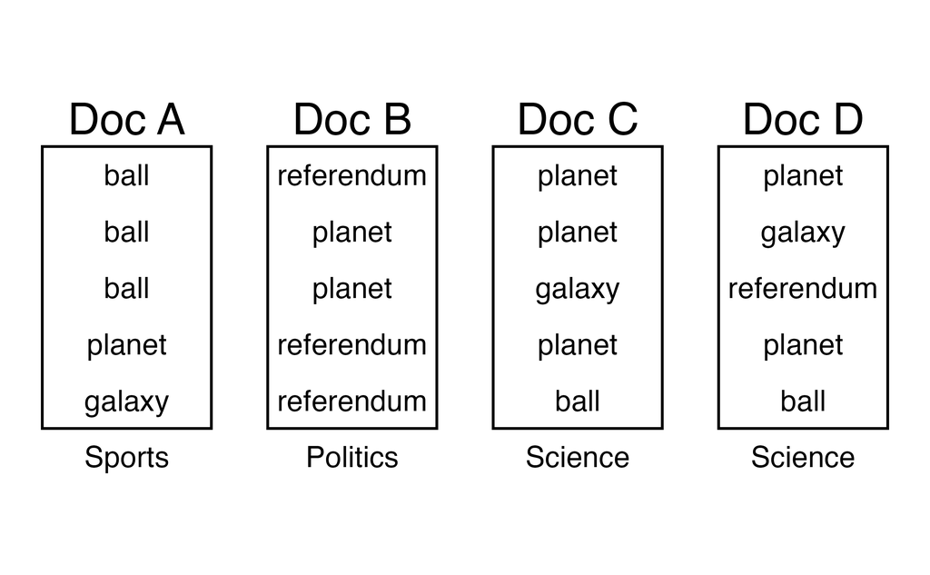

What if you don’t have any idea what the words mean (i.e., what if you are the computer)? It would be much harder to group the words!

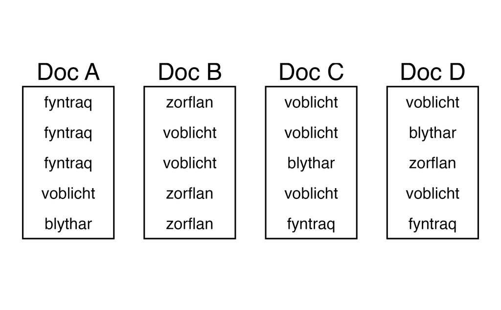

#### Computer assignment of topics

**without** using the definitions of the words, assign generic topics: Topic 1 , Topic 2, Topic 3

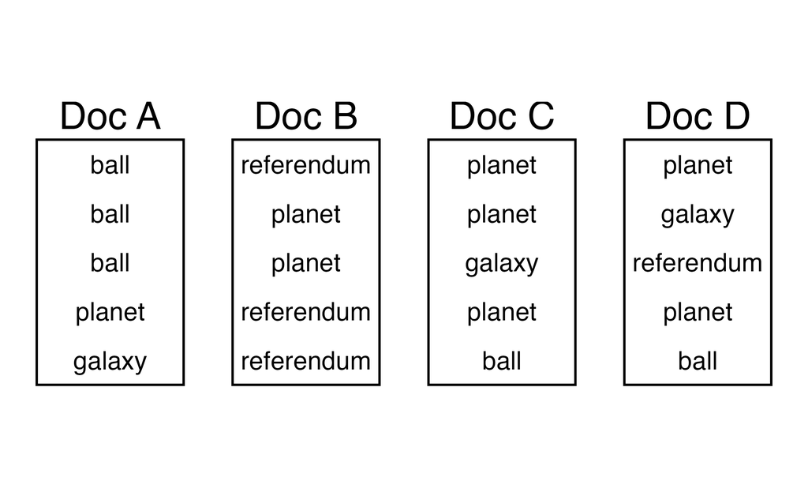

#### Start by assigning a topic to each word

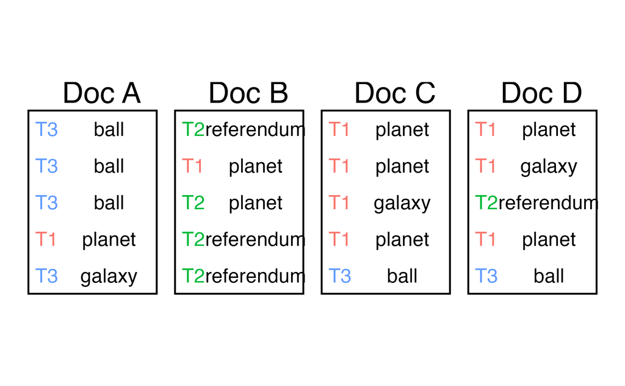

but let’s use colors to make it easier to track…

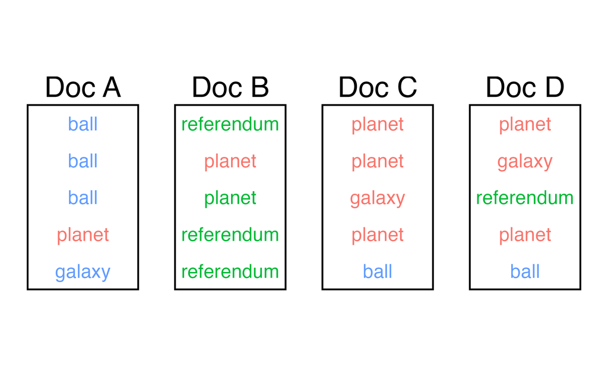

#### How often do we see each topic?

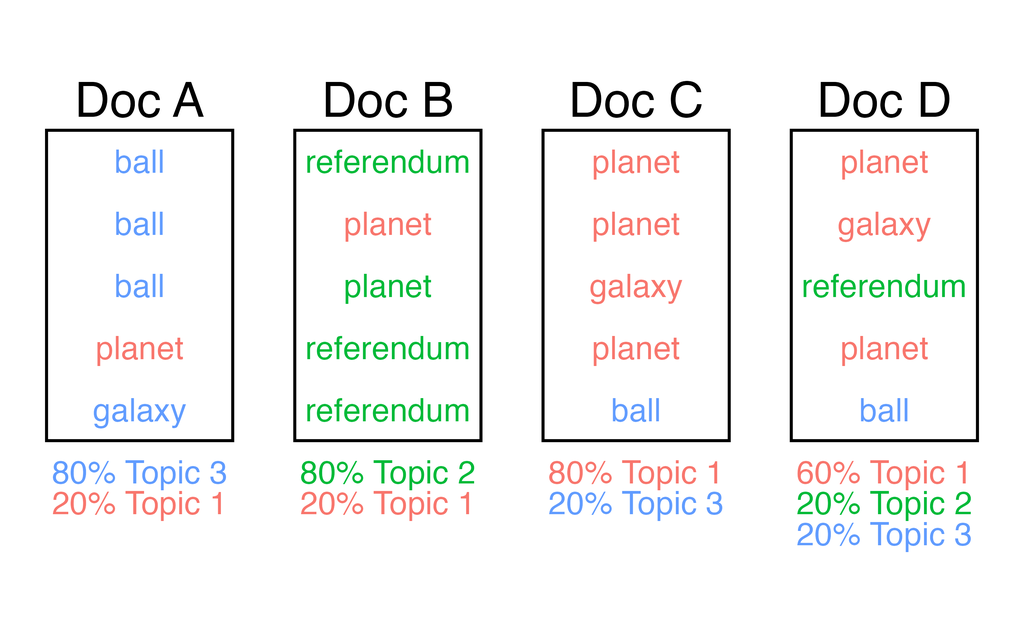

**Property 1:**

articles are as homogeneous as possible

#### What about the words?

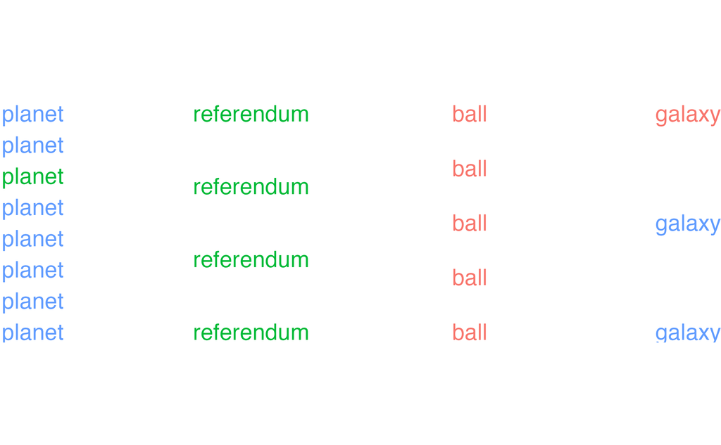

**Property 2:**

words are as homogeneous as possible

#### Goal of LDA:

Color each word with red , green, blue such that

1. articles are as homogeneous as possible
2. words are as homogeneous as possible

#### Gibbs Sampling

Organize the words **one at a time**, trying to make the articles (Goal #1) and words (Goal #2) as consistent as possible.

$\Rightarrow$ assume that all the other words are correct, and try to predict the topic of a given word.

#### Predicting the word’s topic

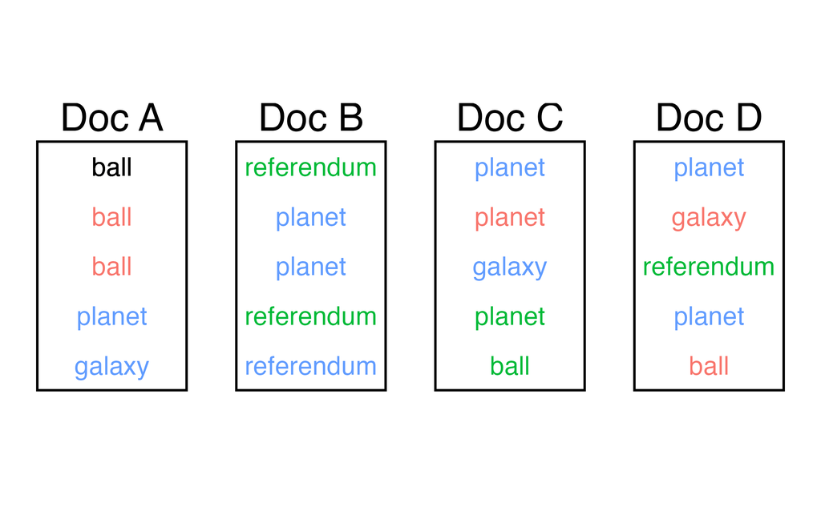

Do we color **ball** red , green, or blue?

#### Predicting the word’s topic (Property #1)

| Topic 1 | Topic 2 | Topic 3 |
| --- | --- | --- |
| Doc A: how many words in Topic 1 | Doc A: how many words in Topic 2 | Doc A: how many words in Topic 3 |
| 2 | 0 | 2 |

#### Predicting the word’s topic (Property #2)

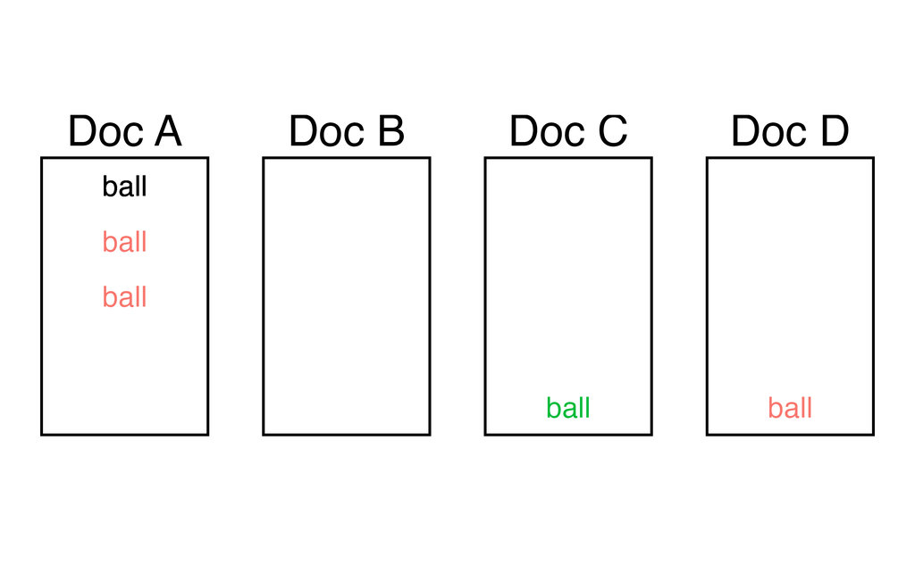

| Topic 1 | Topic 2 | Topic 3 |
| --- | --- | --- |
| How often is **ball** in Topic 1 | How often is **ball** in Topic 2 | How often is **ball** in Topic 3 |
| 3 | 1 | 0 |

#### Probability of topic

$$\begin{align}P(z_i = k' | z_{-i}, W) \propto & \frac{\# \mbox{ words in $d_i$ with $k'$} + \alpha}{\# \mbox{ words in $d_i$ with any topic} + K \cdot \alpha} \cdot \\
&\frac{\# \mbox{ times $i^{th}$ word is in topic $k'$} + \beta}{\# \mbox{ words in topic $k'$} + V \cdot \beta}
\end{align}$$

- $z_i$ is the topic of the $i^{th}$ word
- $z_{-i}$ are the topics of all the words other than the $i^{th}$ word
- $d_i$ is the document of $i^{th}$ word
- $W$ represents all of the words
- $K$ is the total number of topics
- $V$ is the total number of words
- $\alpha$ and $\beta$ are tuning parameter

#### Probability that ball is in each topic

$$\begin{align}P(ball_1 = \mbox{Topic 1} | z_{-i}, W) \propto& \frac{2 + \alpha}{4 + 3 \cdot \alpha} \cdot \frac{3 + \beta}{5 + 4 \cdot \beta}
\end{align}$$

$$\begin{align}P(ball_1 = \mbox{Topic 2} | z_{-i}, W) \propto& \frac{0 + \alpha}{4 + 3 \cdot \alpha} \cdot \frac{1 + \beta}{5 + 4 \cdot \beta}
\end{align}$$

$$\begin{align}P(ball_1 = \mbox{Topic 3} | z_{-i}, W) \propto& \frac{2 + \alpha}{4 + 3 \cdot \alpha} \cdot \frac{0 + \beta}{5 + 4 \cdot \beta}
\end{align}$$

Here, we won’t get into setting $\alpha$ and $\beta$, but for now assume that $\alpha = 0.3$ and $\beta = 0.25.$

$$\require{cancel}
\begin{align}P(ball_1 = \mbox{Topic 1} | z_{-i}, W) \propto& \frac{2 + \cancel{\alpha} \overset{0.3}{}}{4 + 3 \cdot \cancel{\alpha} \overset{0.3}{}} \cdot \frac{3 + \cancel{\beta} \overset{0.25}{}}{5 + 4 \cdot \cancel{\beta} \overset{0.25}{}} = 0.2543
\end{align}$$

$$\begin{align}P(ball_1 = \mbox{Topic 2} | z_{-i}, W) \propto& \frac{0 + \cancel{\alpha} \overset{0.3}{}}{4 + 3 \cdot \cancel{\alpha} \overset{0.3}{}} \cdot \frac{1 + \cancel{\beta} \overset{0.25}{}}{5 + 4 \cdot \cancel{\beta} \overset{0.25}{}} = 0.0128
\end{align}$$

$$\begin{align}P(ball_1 = \mbox{Topic 3} | z_{-i}, W) \propto& \frac{2 + \cancel{\alpha} \overset{0.3}{}}{4 + 3 \cdot \cancel{\alpha} \overset{0.3}{}} \cdot \frac{0 + \cancel{\beta} \overset{0.25}{}}{5 + 4 \cdot \cancel{\beta} \overset{0.25}{}} = 0.0196
\end{align}$$

$\rightarrow$ assign Topic 1 to the first instance of **ball**

#### Next step

Update the first instance of **ball** and move on to the second instance of **ball**. Keep iterating through the words until the words have converged and they aren’t changing topics any longer. (The LDA Gibbs sampler will converge, but only to a local optimum.)

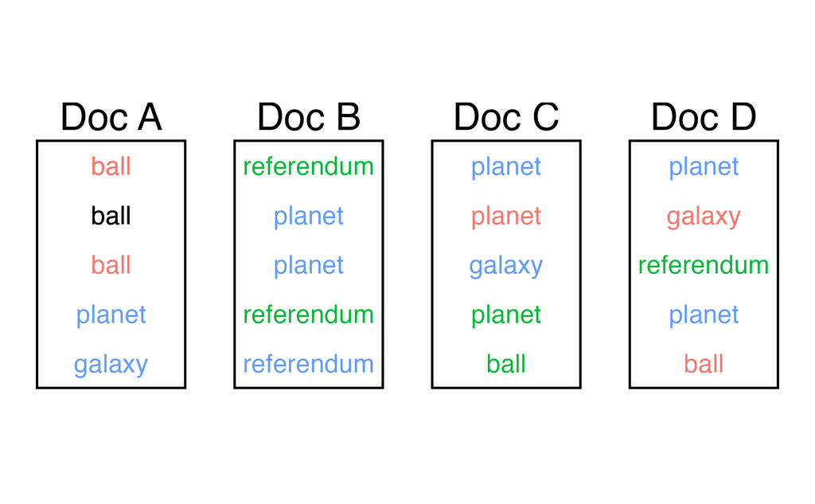

#### What is the topic of a training document?

If we have a document that has already been used to train the LDA, we know the topic allocations for each word in the document.

$$\mbox{Topic}(d) = \mbox{arg} \max_k \theta_{d,k}$$

where $\theta_{d,k}$ is the probability of topic $k$ for document $d$.

$\theta_{d,k}$ is estimated as the proportion of topic $k$ in document $d$.

#### What is the topic of a test document?

For a new document, we do not have a topic allocation for each word in the document.

- For each word in the document, you get a probability for each topic, based on the learned topic-word distribution
- The probability of a topic $k$ for the new document is essentially the weighted sum of the topic probabilities for all the words in the document, considering their relative importance.

#### Example (from Math 154)

**LDA on TSL**

In fall 2015, Benji Lu, Kai Fukutaki, and Ziqi Xiong performed LDA on *The Student Life* articles for their computational statistics project: https://ziqixiong.shinyapps.io/TopicModeling/